# 0_QC: Cyp27a1 KO vs WT – sorted mouse colon epithelium

Published

October 30, 2026

## Overview

Quality control of bulk RNA-seq from FACS-sorted colon epithelial cells (3 WT, 3 *Cyp27a1* KO). Counts were generated with nf-core/rnaseq (salmon) against GENCODE vM25 (GRCm38). The strategy follows `KKIK_bulk/0_QC` (protein-coding filtering, removal of mitochondrial genes, `filterByExpr`, TMM + logCPM, `SummarizedExperiment`/`DGEList` outputs), with checks specific to sorted mouse epithelium:

1. Library size, detected genes, biotype composition and mitochondrial fraction.
2. Sort purity: epithelial markers vs immune/stromal/endothelial/muscle/RBC contamination.
3. Regional identity (colon vs small intestine) and epithelial cell type composition.
4. Dissociation/sorting stress signature (immediate early genes).
5. Sex check (*Xist* vs Y-linked genes) and genotype check (*Cyp27a1*).
6. Gene filtering, normalisation and sample-level similarity (MDS, correlation).

The gene annotation is frozen in `0_QC/outputs/files/annot.csv` (built from the GTF by `0_QC/downloadAnnotation.R`).

```r
library(edgeR)
library(SummarizedExperiment)
library(tidyverse)
library(patchwork)
library(geneplotter)
library(ggrepel)
library(yaml)
library(here)

source(here("functions", "formatting_ggplot.R"))
config <- read_yaml(here("config.yaml"))
genotype_colors <- unlist(config$genotype_colors)

fig_dir <- here("0_QC", "outputs", "figures")
files_dir <- here("0_QC", "outputs", "files")

save_fig <- function(p, name, width, height) {
  ggsave(file.path(fig_dir, name), p, width = width, height = height)
  p
}
```

## Load data

```r
counts_raw <- read.delim(
  here("data", "nfcore_rnaseq", "counts", "salmon.merged.gene_counts.tsv"),
  check.names = FALSE
)
annot <- read.csv(here("0_QC", "outputs", "files", "annot.csv"))
metadata <- read.csv(here("metadata", "metadata.csv")) |>
  mutate(genotype = factor(genotype, levels = c("WT", "KO")))

# salmon estimated counts are non-integer: round for edgeR
counts <- counts_raw |>
  column_to_rownames("gene_id") |>
  dplyr::select(all_of(metadata$sample_id)) |>
  as.matrix() |>
  round()

# all gene ids must be present in the frozen annotation
stopifnot(all(rownames(counts) %in% annot$gene_id))
annot <- annot[match(rownames(counts), annot$gene_id), ]
rownames(annot) <- annot$gene_id

dim(counts)
```

```
[1] 55487     6
```

## Sample-level QC on all genes

```r
lib_size <- colSums(counts)

biotype_group <- case_when(
  annot$chromosome_name == "chrM" ~ "mitochondrial",
  annot$gene_biotype == "protein_coding" ~ "protein_coding",
  annot$gene_biotype == "lncRNA" ~ "lncRNA",
  grepl("rRNA", annot$gene_biotype) ~ "rRNA",
  grepl("pseudogene", annot$gene_biotype) ~ "pseudogene",
  TRUE ~ "other"
)

qc_metrics <- metadata |>
  mutate(
    lib_size = lib_size[sample_id],
    detected_genes = colSums(counts > 0)[sample_id],
    detected_pc_genes = colSums(
      counts[biotype_group == "protein_coding", ] >= 10
    )[sample_id],
    pct_mito = 100 *
      colSums(counts[biotype_group == "mitochondrial", ])[sample_id] /
      lib_size,
    pct_rRNA = 100 *
      colSums(counts[biotype_group == "rRNA", ])[sample_id] / lib_size,
    pct_protein_coding = 100 *
      colSums(counts[biotype_group == "protein_coding", ])[sample_id] /
      lib_size
  )

qc_metrics |>
  mutate(across(where(is.numeric), \(x) round(x, 2))) |>
  knitr::kable()
```

| sample_id | mouse | genotype | cell_type | tissue | lib_size | detected_genes | detected_pc_genes | pct_mito | pct_rRNA | pct_protein_coding |
| --- | --- | --- | --- | --- | --- | --- | --- | --- | --- | --- |
| A1_WT_Epi | A1 | WT | epithelium | colon | 51236839 | 20435 | 13412 | 8.64 | 0 | 87.38 |
| A2_WT_Epi | A2 | WT | epithelium | colon | 44755293 | 21545 | 13468 | 8.53 | 0 | 86.95 |
| A3_WT_Epi | A3 | WT | epithelium | colon | 42757057 | 20229 | 13319 | 11.06 | 0 | 84.47 |
| B1_KO_Epi | B1 | KO | epithelium | colon | 45888611 | 21093 | 13650 | 10.17 | 0 | 85.12 |
| B2_KO_Epi | B2 | KO | epithelium | colon | 48543972 | 20484 | 13548 | 10.59 | 0 | 84.87 |
| B3_KO_Epi | B3 | KO | epithelium | colon | 44034649 | 19787 | 13339 | 11.79 | 0 | 83.69 |

### Library size

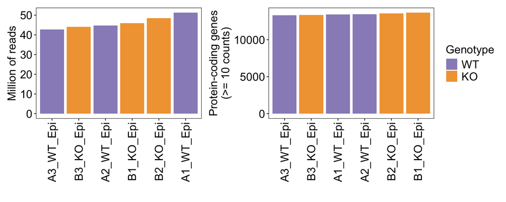

```r
bar_metric <- function(df, y, ylab) {
  df |>
    mutate(sample_id = factor(sample_id, levels = sample_id[order(.data[[y]])])) |>
    ggplot(aes(x = sample_id, y = .data[[y]], fill = genotype)) +
    geom_col() +
    scale_fill_manual(values = genotype_colors) +
    my_theme +
    theme(axis.text.x = element_text(angle = 90, hjust = 1, vjust = .5)) +
    labs(x = "", y = ylab, fill = "Genotype")
}

p_lib <- (
  bar_metric(mutate(qc_metrics, lib_size = lib_size / 1e6), "lib_size", "Million of reads") |
    bar_metric(qc_metrics, "detected_pc_genes", "Protein-coding genes\n(>= 10 counts)")
) +
  plot_layout(guides = "collect")

save_fig(p_lib, "libsize_barplot.pdf", 10, 4)
```

### Biotype composition and mitochondrial fraction

A high mitochondrial fraction in sorted epithelium points to stressed or dying cells (or cytoplasmic RNA loss) during dissociation and sorting. rRNA should be low after poly(A) selection.

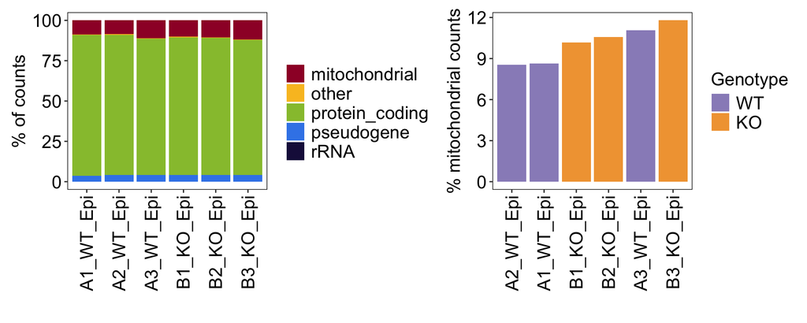

```r
biotype_df <- rowsum(counts, biotype_group) |>
  as.data.frame() |>
  rownames_to_column("biotype") |>
  pivot_longer(-biotype, names_to = "sample_id", values_to = "counts") |>
  group_by(sample_id) |>
  mutate(pct = 100 * counts / sum(counts)) |>
  ungroup() |>
  left_join(metadata, by = "sample_id")

p_biotype <- ggplot(biotype_df, aes(x = sample_id, y = pct, fill = biotype)) +
  geom_col() +
  scale_fill_manual(values = get_color_list(6)) +
  my_theme +
  theme(axis.text.x = element_text(angle = 90, hjust = 1, vjust = .5)) +
  labs(x = "", y = "% of counts", fill = "")

p_mito <- bar_metric(qc_metrics, "pct_mito", "% mitochondrial counts")

save_fig(p_biotype | p_mito, "biotypes_mito.pdf", 10, 4)
```

### Most abundant genes

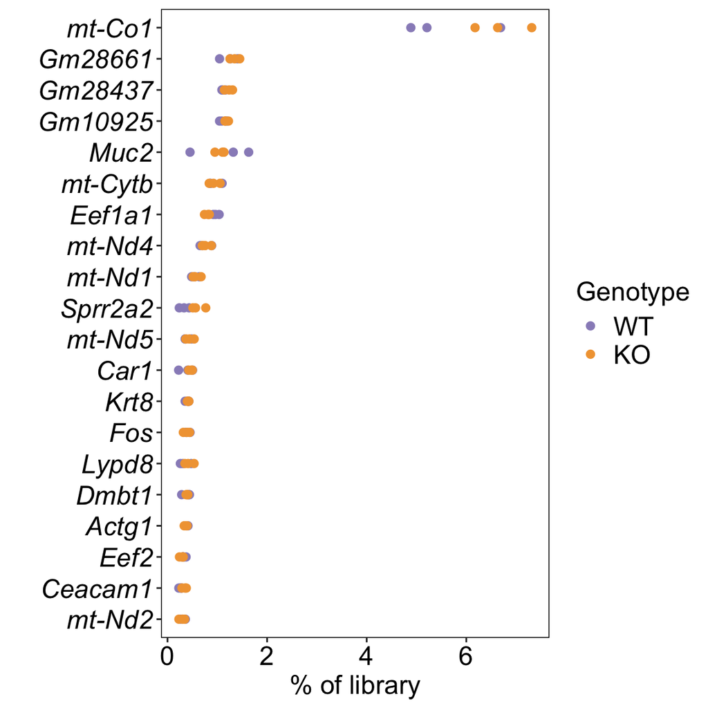

```r
top_genes <- names(sort(rowMeans(cpm(counts)), decreasing = TRUE))[1:20]

top_df <- (100 * t(t(counts[top_genes, ]) / lib_size)) |>
  as.data.frame() |>
  rownames_to_column("gene_id") |>
  mutate(gene = annot[gene_id, "external_gene_name"]) |>
  pivot_longer(-c(gene_id, gene), names_to = "sample_id", values_to = "pct") |>
  left_join(metadata, by = "sample_id") |>
  mutate(gene = factor(gene, levels = rev(unique(annot[top_genes, "external_gene_name"]))))

p_top <- ggplot(top_df, aes(x = pct, y = gene, color = genotype)) +
  geom_point(size = 2) +
  scale_color_manual(values = genotype_colors) +
  my_theme +
  theme(axis.text.y = element_text(face = "italic")) +
  labs(x = "% of library", y = "", color = "Genotype")

save_fig(p_top, "top20_genes.pdf", 6, 6)
```

## Sorted epithelium-specific checks

```r
# logCPM on gene symbols for marker inspection (all genes, before filtering)
symbol_counts <- rowsum(counts, annot$external_gene_name)
logcpm_all <- cpm(symbol_counts, log = TRUE)

marker_heatmap <- function(markers, value_name = "logCPM") {
  markers <- markers |> filter(gene %in% rownames(logcpm_all))
  logcpm_all[markers$gene, , drop = FALSE] |>
    as.data.frame() |>
    rownames_to_column("gene") |>
    pivot_longer(-gene, names_to = "sample_id", values_to = "logCPM") |>
    left_join(markers, by = "gene") |>
    left_join(metadata, by = "sample_id") |>
    mutate(
      gene = factor(gene, levels = rev(markers$gene)),
      group = factor(group, levels = unique(markers$group))
    ) |>
    ggplot(aes(x = sample_id, y = gene, fill = logCPM)) +
    geom_tile() +
    geom_text(aes(label = round(logCPM, 1)), size = 3) +
    facet_grid(group ~ genotype, scales = "free", space = "free") +
    scale_fill_distiller(palette = "RdYlBu", direction = -1) +
    hmtheme +
    theme(strip.text.y = element_text(angle = 0, hjust = 0)) +
    labs(fill = value_name)
}
```

### Sort purity

Sorted epithelial cells should express high *Epcam*/*Cdh1*/*Vil1* and show little to no signal for haematopoietic (*Ptprc*), stromal, endothelial, smooth muscle, glial or red blood cell genes. Contamination markers at logCPM > ~3 in a subset of samples would point to sorting impurity and could confound KO vs WT differences.

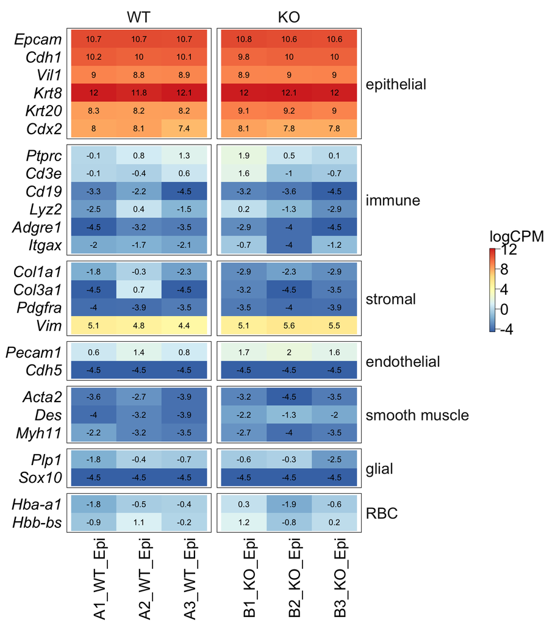

```r
purity_markers <- tribble(
  ~gene, ~group,
  "Epcam", "epithelial",
  "Cdh1", "epithelial",
  "Vil1", "epithelial",
  "Krt8", "epithelial",
  "Krt20", "epithelial",
  "Cdx2", "epithelial",
  "Ptprc", "immune",
  "Cd3e", "immune",
  "Cd19", "immune",
  "Lyz2", "immune",
  "Adgre1", "immune",
  "Itgax", "immune",
  "Col1a1", "stromal",
  "Col3a1", "stromal",
  "Pdgfra", "stromal",
  "Vim", "stromal",
  "Pecam1", "endothelial",
  "Cdh5", "endothelial",
  "Acta2", "smooth muscle",
  "Des", "smooth muscle",
  "Myh11", "smooth muscle",
  "Plp1", "glial",
  "Sox10", "glial",
  "Hba-a1", "RBC",
  "Hbb-bs", "RBC"
)

save_fig(marker_heatmap(purity_markers), "purity_markers.pdf", 8, 9)
```

### Regional identity and epithelial composition

Colon identity (*Car1*, *Satb2*, *Slc26a3*, *Aqp8*) should dominate over small-intestinal genes (*Fabp6*, *Lct*, *Apoa4*, *Fabp2*). Comparable levels of lineage markers (stem, proliferation, goblet, enteroendocrine, tuft, colonocyte) across samples indicate a similar composition of the sorted epithelium; a shift could reflect the genotype or a different sampled segment (proximal vs distal colon: *Car1*/*Hoxb13* gradients).

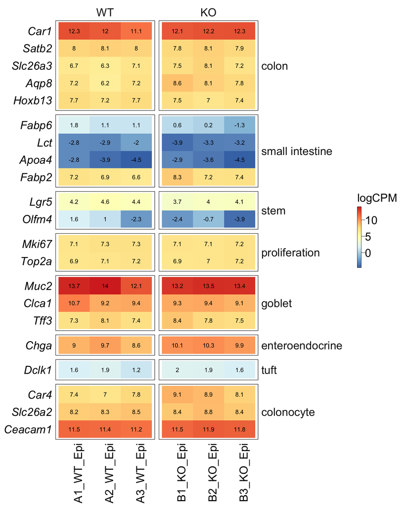

```r
composition_markers <- tribble(
  ~gene, ~group,
  "Car1", "colon",
  "Satb2", "colon",
  "Slc26a3", "colon",
  "Aqp8", "colon",
  "Hoxb13", "colon",
  "Fabp6", "small intestine",
  "Lct", "small intestine",
  "Apoa4", "small intestine",
  "Fabp2", "small intestine",
  "Lgr5", "stem",
  "Olfm4", "stem",
  "Mki67", "proliferation",
  "Top2a", "proliferation",
  "Muc2", "goblet",
  "Clca1", "goblet",
  "Tff3", "goblet",
  "Chga", "enteroendocrine",
  "Dclk1", "tuft",
  "Car4", "colonocyte",
  "Slc26a2", "colonocyte",
  "Ceacam1", "colonocyte"
)

save_fig(marker_heatmap(composition_markers), "composition_markers.pdf", 8, 10)
```

### Dissociation / sorting stress

Enzymatic dissociation and FACS induce immediate early and heat-shock genes (van den Brink et al., 2017). Strong differences between samples here are technical and should be considered in downstream models if unbalanced between genotypes.

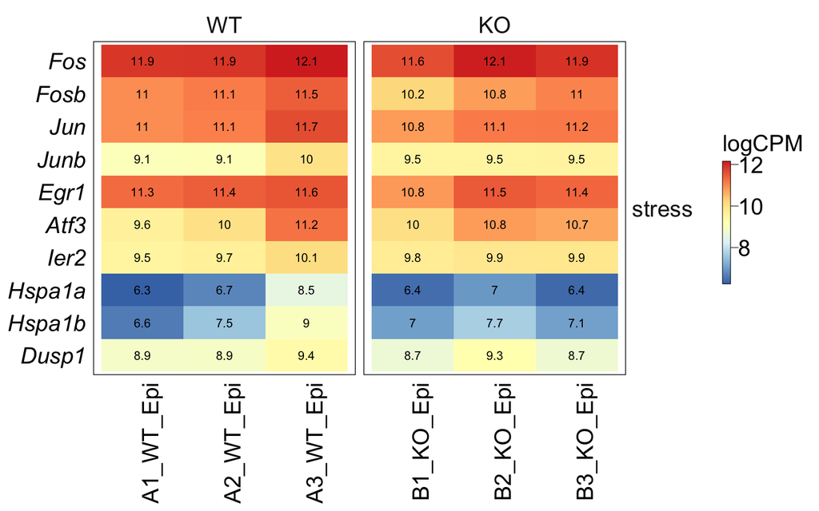

```r
stress_markers <- tibble(
  gene = c("Fos", "Fosb", "Jun", "Junb", "Egr1", "Atf3", "Ier2", "Hspa1a", "Hspa1b", "Dusp1"),
  group = "stress"
)

save_fig(marker_heatmap(stress_markers), "stress_markers.pdf", 8, 5)
```

### Sex check

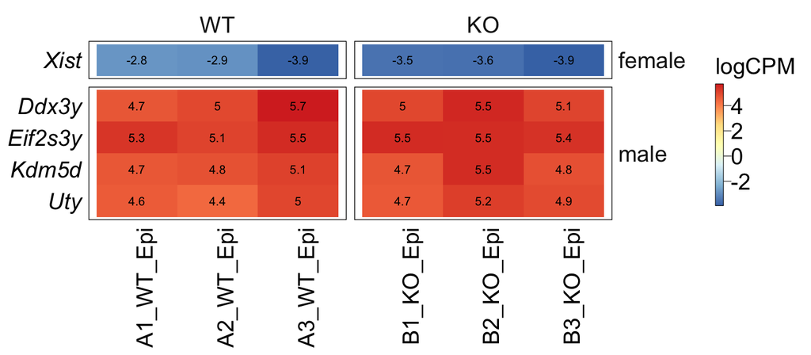

```r
sex_markers <- tribble(
  ~gene, ~group,
  "Xist", "female",
  "Ddx3y", "male",
  "Eif2s3y", "male",
  "Kdm5d", "male",
  "Uty", "male"
)

save_fig(marker_heatmap(sex_markers), "sex_markers.pdf", 8, 3.5)
```

```r
qc_metrics <- qc_metrics |>
  mutate(
    inferred_sex = if_else(
      logcpm_all["Xist", sample_id] > colMeans(logcpm_all[c("Ddx3y", "Eif2s3y", "Kdm5d", "Uty"), sample_id]),
      "female",
      "male"
    )
  )
table(qc_metrics$inferred_sex, qc_metrics$genotype)
```

```
       WT KO
  male  3  3
```

### Genotype check: *Cyp27a1*

Expression of *Cyp27a1* per sample. Depending on the KO allele design (exon deletion, frameshift, conditional deletion in epithelium), transcript may still be detected in KO samples; a definitive check requires coverage over the targeted exon(s) (bigwig/BAM).

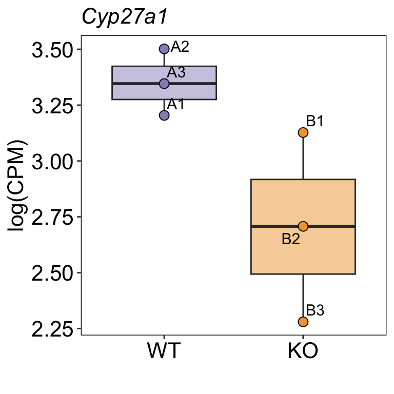

```r
cyp_df <- tibble(
  sample_id = colnames(logcpm_all),
  logCPM = logcpm_all["Cyp27a1", ],
  counts = symbol_counts["Cyp27a1", ]
) |>
  left_join(metadata, by = "sample_id")

p_cyp <- ggplot(cyp_df, aes(x = genotype, y = logCPM, fill = genotype)) +
  geom_boxplot(outlier.alpha = 0, alpha = .5) +
  geom_point(shape = 21, size = 3) +
  geom_text_repel(aes(label = mouse), size = 4) +
  scale_fill_manual(values = genotype_colors) +
  my_theme +
  theme(legend.position = "none", plot.title = element_text(face = "italic")) +
  labs(x = "", y = "log(CPM)", title = "Cyp27a1")

save_fig(p_cyp, "cyp27a1_expression.pdf", 4, 4)
```

```r
cyp_df |> dplyr::select(sample_id, genotype, counts, logCPM) |> knitr::kable(digits = 2)
```

| sample_id | genotype | counts | logCPM |
| --- | --- | --- | --- |
| A1_WT_Epi | WT | 470 | 3.20 |
| A2_WT_Epi | WT | 505 | 3.50 |
| A3_WT_Epi | WT | 433 | 3.35 |
| B1_KO_Epi | KO | 399 | 3.13 |
| B2_KO_Epi | KO | 315 | 2.71 |
| B3_KO_Epi | KO | 212 | 2.28 |

## Gene filtering and normalisation

Same steps as `KKIK_bulk/0_QC`: keep protein-coding genes, remove mitochondrially-encoded genes, collapse to gene symbols, filter lowly expressed genes with `filterByExpr` (grouped by genotype), TMM-normalise and compute logCPM. The KKIK-specific second filter (> 25 counts in > 30 samples) was designed for a cohort of > 100 samples and is not applied here; with n = 3 per group, `filterByExpr` requires a minimum count in at least 3 samples.

```r
# protein-coding, nuclear genes
keep_pc <- annot$gene_biotype == "protein_coding" & annot$chromosome_name != "chrM"
counts_pc <- counts[keep_pc, ]

# collapse duplicated symbols
genes_counts <- rowsum(counts_pc, annot[keep_pc, "external_gene_name"])
genes_counts <- genes_counts[order(rownames(genes_counts)), ]

# rowData: one row per symbol (first gene id when symbols are duplicated)
gene_data <- annot[keep_pc, ]
gene_data <- gene_data[match(rownames(genes_counts), gene_data$external_gene_name), ]
rownames(gene_data) <- gene_data$external_gene_name

se <- SummarizedExperiment(
  assays = list(counts = genes_counts),
  colData = metadata |> left_join(qc_metrics |> dplyr::select(sample_id, inferred_sex), by = "sample_id"),
  rowData = gene_data
)
colnames(se) <- se$sample_id

dge <- DGEList(
  counts = assays(se)$counts,
  genes = as.data.frame(rowData(se)),
  samples = as.data.frame(colData(se)),
  group = se$genotype
)

mask <- filterByExpr(dge, group = dge$samples$genotype)
dge.filt <- dge[mask, , keep.lib.sizes = FALSE]
se.filt <- se[mask, ]
dge.filt <- calcNormFactors(dge.filt)
assays(se.filt)$logCPM <- cpm(dge.filt, log = TRUE)
se.filt$norm.factors <- dge.filt$samples$norm.factors

tibble(
  step = c("all genes", "protein-coding nuclear", "collapsed symbols", "filterByExpr"),
  n_genes = c(nrow(counts), nrow(counts_pc), nrow(genes_counts), sum(mask))
) |>
  knitr::kable()
```

| step | n_genes |
| --- | --- |
| all genes | 55487 |
| protein-coding nuclear | 21923 |
| collapsed symbols | 21887 |
| filterByExpr | 13456 |

```r
dge.filt$samples |>
  dplyr::select(sample_id, genotype, lib.size, norm.factors) |>
  knitr::kable(digits = 3)
```

|  | sample_id | genotype | lib.size | norm.factors |
| --- | --- | --- | --- | --- |
| A1_WT_Epi | A1_WT_Epi | WT | 44763295 | 0.960 |
| A2_WT_Epi | A2_WT_Epi | WT | 38905465 | 0.980 |
| A3_WT_Epi | A3_WT_Epi | WT | 36108403 | 1.033 |
| B1_KO_Epi | B1_KO_Epi | KO | 39051136 | 0.982 |
| B2_KO_Epi | B2_KO_Epi | KO | 41190790 | 1.030 |
| B3_KO_Epi | B3_KO_Epi | KO | 36846613 | 1.018 |

### Distribution of logCPM

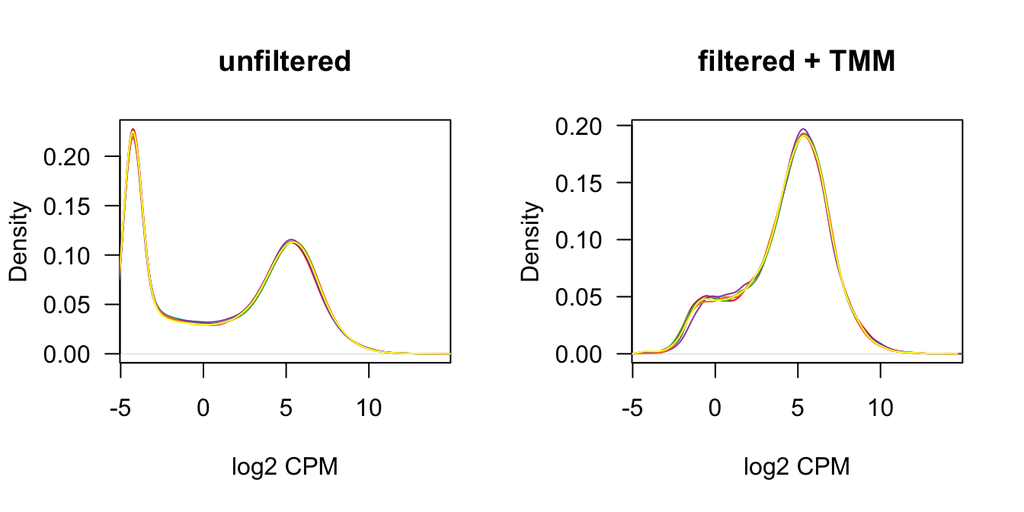

```r
plot_density <- function() {
  par(mfrow = c(1, 2))
  multidensity(
    as.list(as.data.frame(cpm(dge, log = TRUE))),
    xlab = "log2 CPM",
    legend = NULL,
    main = "unfiltered",
    las = 1
  )
  multidensity(
    as.list(as.data.frame(assays(se.filt)$logCPM)),
    xlab = "log2 CPM",
    legend = NULL,
    main = "filtered + TMM",
    las = 1
  )
}

pdf(file.path(fig_dir, "multidensity.pdf"), width = 7, height = 3.5)
plot_density()
invisible(dev.off())
plot_density()
```

### Sample similarity

Samples should not separate by technical metrics; outliers in MDS or the correlation matrix are cross-checked against the metrics above.

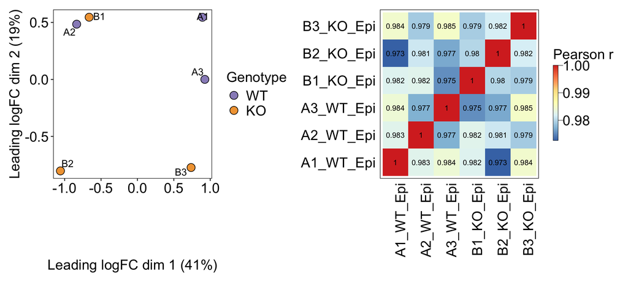

```r
mds <- plotMDS(dge.filt, plot = FALSE)
mds_df <- tibble(
  sample_id = colnames(dge.filt),
  dim1 = mds$x,
  dim2 = mds$y
) |>
  left_join(qc_metrics, by = "sample_id")

p_mds <- ggplot(mds_df, aes(x = dim1, y = dim2, fill = genotype)) +
  geom_point(shape = 21, size = 4) +
  geom_text_repel(aes(label = mouse), size = 4) +
  scale_fill_manual(values = genotype_colors) +
  my_theme +
  labs(
    x = paste0("Leading logFC dim 1 (", round(100 * mds$var.explained[1]), "%)"),
    y = paste0("Leading logFC dim 2 (", round(100 * mds$var.explained[2]), "%)"),
    fill = "Genotype"
  )

cor_df <- cor(assays(se.filt)$logCPM, method = "pearson") |>
  as.data.frame() |>
  rownames_to_column("sample_1") |>
  pivot_longer(-sample_1, names_to = "sample_2", values_to = "r")

p_cor <- ggplot(cor_df, aes(x = sample_1, y = sample_2, fill = r)) +
  geom_tile() +
  geom_text(aes(label = round(r, 3)), size = 3) +
  scale_fill_distiller(palette = "RdYlBu", direction = -1) +
  hmtheme +
  theme(axis.text.y = element_text(face = "plain")) +
  labs(fill = "Pearson r")

save_fig(p_mds | p_cor, "mds_correlation.pdf", 10, 4.5)
```

## Save outputs

```r
saveRDS(se.filt, file.path(files_dir, "se.rds"))
saveRDS(dge.filt, file.path(files_dir, "dge.rds"))
write.csv(qc_metrics, file.path(files_dir, "qc_metrics.csv"), row.names = FALSE)

writeLines(capture.output(sessionInfo()), here("0_QC", "sessionInfo.txt"))
```